# STEP 2: DADA2 Post-processing

This notebook details several data processing steps requiring decisions following output of ASV and taxonomy tables from the `dada2` pipeline (Step 1). The final outputs are the bacterial ASV table with host-derived chloroplast and mitochondria ASVs vetted and summed up, as well as column with the sum of all fungal sequences assigned by their mtDNA hits to `nr` via BLAST.

First we re-enter the data output from DADA2 pipeline from the **R** scripts found in notebook `01_DADA2_pipeline_v1.Rmd`:

```r
data.path <- "/Users/phumph/Dropbox/Phyllosphere_project/analysis_phy/16S_seq/" # change to local data path for repeating this analysis.
TAB <- read.csv(paste0(data.path,"seqs_through_pipe_v1.csv"),T)               # output from 01_DADA2_pipeline
ASV <- read.csv(paste0(data.path,"dada2_ASV_table_v3.csv"),T, row.names = 1)  # output from 01_DADA2_pipeline
TAX <- read.csv(paste0(data.path,"dada2_taxa_Silva_wSpp_uniques_v1.csv"),T)   # output from 01_DADA2_pipeline
```

First, we need to retain only samples relevant to the field studies relevant for the present analysis. This pipeline was used to identify ASVs across a wider range of samples than will be reported here.

We have a total of 324 samples spread across the two field sites (EL and NPB). For these libraries, let’s examine the reads that made it through the pipeline:

```r
track2 <- melt(TAB2)
track.p1 <- ggplot(track2, aes(x = variable, y = log(value,10), group = X, alpha = 0.1)) +
  geom_line(col = "midnightblue") +
  xlab("") + ylab("log10 reads") + theme_phy1() +
  theme(legend.position = "none")
track.p2 <- ggplot(data.frame(TAB2), aes(x = nonchim/input)) +
  geom_histogram(bins = 40) +
  xlab("prop. of reads at endpoint") + theme_phy1()
pdf(file = here("figs/reads_through_pipe.pdf"), width = 6, height = 2)
  ggarrange(plotlist = list(track.p1,track.p2), ncol = 2)
dev.off()
```

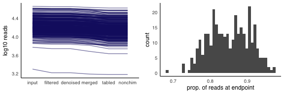

```r
ggarrange(plotlist = list(track.p1,track.p2), ncol = 2)
```

```r
# prune ASVs from TAX and ASV2:
# define prevalence
cm <- as.matrix(ASV2)
cm[cm != 0] <- 1
prevs <- colSums(cm)
# identify sequences found in only 1 library:
singletons <- prevs[prevs < 1]

# remove these OTUs from ASV2 as well as TAX. Need to find row indexes for TAX, since no sequence as col.
rownames(TAX) <- names(ASV2)
TAX2 <- dplyr::filter(TAX, !rownames(TAX) %in% names(singletons))
rownames(TAX2) <- TAX2[,'X']
ASV3 <- ASV2[,!names(ASV2) %in% names(singletons)]
```

This removed 394 ASVs from the data, leaving us with 1278 total ASVs. This reduced ASV set still includes host-derived ASVs from the chloroplast and mitochondria. We will want to retain vetted host-derived 16S counts while excluding spurious chloroplast hits as well as non-host mitochondrial hits (e.g. fungal mtDNA reads). The latter category can be totalled to represent a fungal category that itself may vary across samples in meaningful ways.

### Dealing with host-derived ASVs

The first step is to increase our taxonomic resolution on any putatively host-derived ASV. We start by pulling out all of the ASVs with an RDP-defined hit to chloroplast or mitochondria:

```r
cp <- grep("Chloroplast", TAX2[,'unique.id'])
mt <- grep("Mitochondria", TAX2[,'unique.id'])
```

```r
# export sequences for mt and cp ASVs (FASTA format)
cp_seq_name <- paste0('>seq',rownames(TAX2)[cp])
cp_seqs <- rownames(TAX2)[cp]

mt_seq_name <- paste0('>seq',rownames(TAX2)[mt])
mt_seqs <- rownames(TAX2)[mt]

# create interleaved character vectors of sequences and names:
MT <- character(length(mt_seqs) * 2)
MT[c(TRUE, FALSE)] <- mt_seq_name
MT[c(FALSE, TRUE)] <- mt_seqs
writeLines(MT, con = paste0(data.path,"mtASV_seqs.fasta"), sep = "\n")

CP <- character(length(cp_seqs) * 2)
CP[c(TRUE, FALSE)] <- cp_seq_name
CP[c(FALSE, TRUE)] <- cp_seqs
writeLines(CP, con = paste0(data.path,"cpASV_seqs.fasta"), sep = "\n")

# performed manual blast via ncbi web interface with default parameters for each file separately, setting number of aligned results to 10.
# export each as a as Hit Table ("cp_hit_table.csv"", "mt_hit_table.csv").
```

Now we can re-import the Hit tables saved as `.csv` back into R and parse the results:

```r
# classify all taxon_IDs
# NCBI has a ceiling on the number of requests per second without an API key. I've requested my own key via
# https://www.ncbi.nlm.nih.gov/account/
# this change went into effect May 2018 (https://www.ncbi.nlm.nih.gov/books/NBK25500/ for documentation)
# see https://github.com/ropensci/taxize/issues/666 for more details (as of 26 June 2018)
# also see taxize e-book details here: https://ropensci.github.io/taxize-book/authentication.html
# ENTREZ_KEY stored in .Renviron file in local git repo dir
mt_class.all <- classification(unique(mtbr_gi[,'tax_ID']), callopts = list(), return_id = TRUE, db = 'ncbi')
```

[output not shown]

Below is a plot of the identified mitochondrial sequences present in the dataset, broken down by lowest-level NCBI-based taxonomic hierarchy:

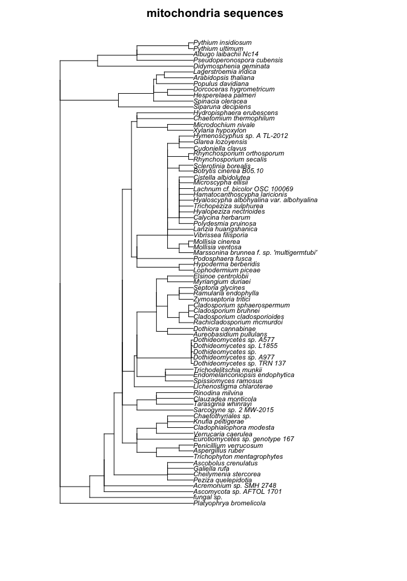

Note the plethora of fungal sequences. The plant mtDNA sequences clade out around *Arabidopsis thaliana* (which is our *de facto* focal taxon, since the *Cardamine macrophylla* mitochondrial genome has not apparently been annotated). We will exclude all non-Arabidopsis plant mtDNA ASVs and sum all of the fungal mtDNA ASVs into a fungal class that may also co-vary with measured covariates in our experiments. Note also that the “uncultured” taxa sister to the rest may not actually be sister when considering the molecular phylogeny of the mt ASVs themselves. We will return to this later and place these ASVs to determine how to deal with them.

And now for the chloroplast sequences:

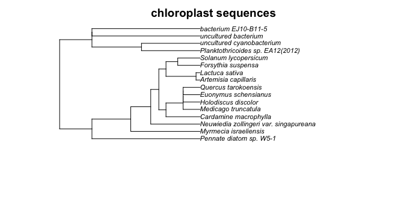

We will exclude all non-*Cardamine macrophylla* cpDNA ASVs. This taxon has the closest sequenced chloroplast genome to *C. cordifolia.* We are grateful that it is in the NCBI database (Ren et al. 2017)[https://link.springer.com/article/10.1007/s12686-017-0880-4].

We must first re-map this taxonomic information back onto the ASVs in order to plot the abundance of each of these taxonomic classes. We should see that *Cardamine* or *Arabidopsis* hits should be overwhelmingly abundant, for both cp and mtDNA, while others will comprise a relatively small proportion of the data.

```r
# sum up all ASV counts across all samples
ASV_sums <- colSums(ASV3)
# subset this named vector of sums by the cp and mt ASVs:
cpASVs <- data.frame(tot = ASV_sums[paste0('seq',names(ASV_sums)) %in% paste0(cpres[,'seqid'])])
mtASVs <- data.frame(tot = ASV_sums[paste0('seq',names(ASV_sums)) %in% paste0(mtres[,'seqid'])])
cpASVs[,'seqid'] <- paste0('seq',rownames(cpASVs))
mtASVs[,'seqid'] <- paste0('seq',rownames(mtASVs))
# add abundance data to cpbr3 and mtbr3:
mtres[,'tot'] <- sapply(mtres[,'seqid'], function(x) mtASVs[,'tot'][match(x, mtASVs[,'seqid'])])
cpres[,'tot'] <- sapply(cpres[,'seqid'], function(x) cpASVs[,'tot'][match(x, cpASVs[,'seqid'])])
# mtres2 <- merge(mtres, mtASVs, by = 'seqid', sort = F)
# cpres2 <- merge(cpres, cpASVs, by = 'seqid', sort = F)
# total by name
mtres2 <- data.frame(dplyr::group_by(mtres, tax_ID) %>% summarise(total = sum(tot)) %>% arrange(desc(total)))
cpres2 <- data.frame(dplyr::group_by(cpres, tax_ID) %>% summarise(total = sum(tot)) %>% arrange(desc(total)))
mtres2[,'f'] <- mtres2[,'total']/sum(mtres2[,'total'])
cpres2[,'f'] <- cpres2[,'total']/sum(cpres2[,'total'])
# merge back with names
mtres2[,'name'] <- sapply(mtres2[,'tax_ID'], function(x) mtres[,'name'][match(x, mtres[,'tax_ID'])])
mtres2[,'name'] <- factor(mtres2[,'name'], levels = mtres2[,'name'])
cpres2[,'name'] <- sapply(cpres2[,'tax_ID'], function(x) cpres[,'name'][match(x, cpres[,'tax_ID'])])
cpres2[,'name'] <- factor(cpres2[,'name'], levels = cpres2[,'name'])
```

Below is a plot of the mtDNA ASVs summed by taxonomic name:

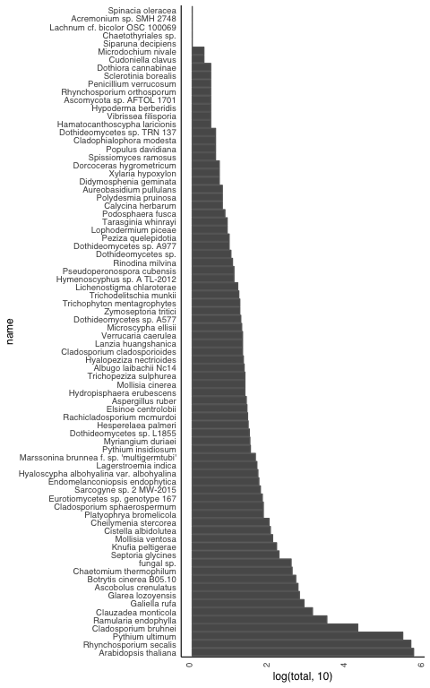

```r
# make plots:
ggplot(mtres2, aes(x = name, y = log(total,10))) +
  geom_bar(stat = "identity", col = "gray40") + theme_phy1() +
  theme(axis.text.x = element_text(angle = 90, hjust = 1, vjust = 0)) +
  coord_flip()
```

And now for the cpDNA ASVs, similarly binned by NCBI lowest taxon:

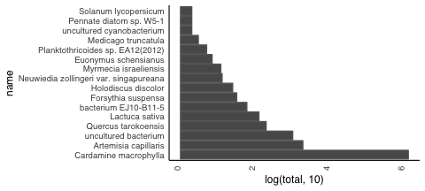

```r
ggplot(cpres2, aes(x = name, y = log(total,10))) +
  geom_bar(stat = "identity", col = "gray40") + theme_phy1() +
  theme(axis.text.x = element_text(angle = 90, hjust = 1, vjust = 0)) +
  coord_flip()
```

### Phylogenies of mt and cp ASVs

As a final sanity-check, let’s export all of these vetted ASVs and produce a phylogeny to better understand whether we have appropriately captured the evolutionary distances among these sequences. It is possible that the “uncultured bacterium” assigned taxonomy is masking the fact that these samples represent a diverse set that nest across the cp-derived 16S sequences in our dataset. We will generate ML phylogenies of the unique cp ASVs and designate a criteria for lumping ASVs into the Cardamine-derived set.

Let’s plot the best ML tree:

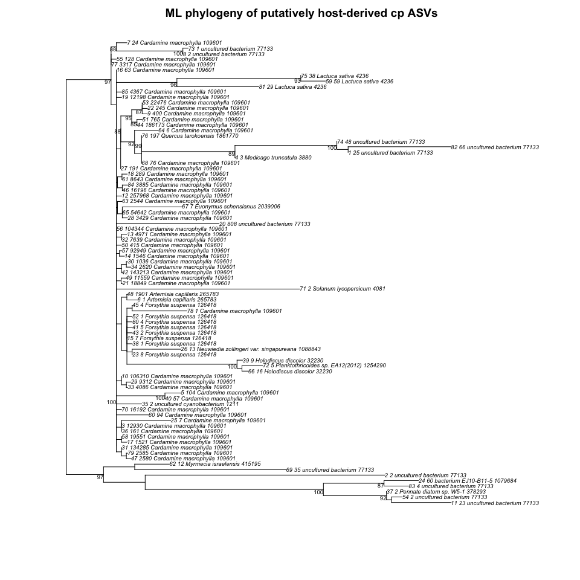

```r
# plot consensus tree with ML node labels
# pdf(file = "cpASV_ML_tree_1.pdf", width = 8, height = 8)
#   plotBS(midpoint(fit$tree), bs, p = 80, type="p", cex = 0.6, main = "ML phylogeny of putatively host-derived cp ASVs")
# dev.off()
plotBS(midpoint(fit$tree), bs, p = 80, type="p", cex = 0.6, main = "ML phylogeny of putatively host-derived cp ASVs")
```

This is a mid-point rooted tree, which makes some of the relationships in the middle hard to see. But we *can* see a well-supported node clading out sister to the major node up top, which appears to contain only non-identified and green algal cp 16S hits (also includes a Pennate diatom sequence). These ASVs will be removed. Besides that, there is a second clade of cp ASVs that contain no *Cardamine*-annotated ASVs; the rooted tree gives the appearance that they are nested within the large *Cardamine*-derived ASV clade, but there is a long branch separating this group from any of the *Cardamine* sequences. We will also prune these ASVs from the table. As for the other ASVs that clade with *Cardamine*, there is a separate plant clade that is well-supported that likely corresponds to actual contaminating sequences in these libraries. In general, this topology strongly suggests that a reasonable way to proceed is to simply excude all cp ASVs that were not annotated as *Cardamine*.

Excluding non-*Cardamine* cp ASVs removed 0.27 percent of the cp reads from the data, a negligible fraction.

In a later analysis, we will re-run a ML phylogeny using the vetted *Cardamine* cp 16S sequences to test for geographic differentiation in haplotypes between NPB and EL populations. For now, we will repeat the above analysis for the mtASVs and construct our composite `mt` column for this host-derived organelle.

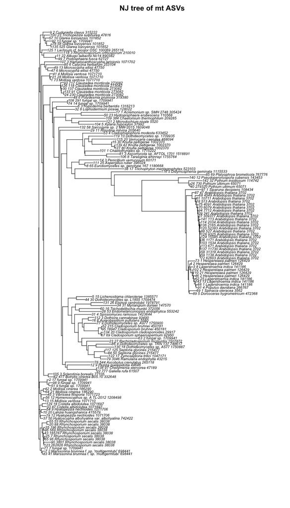

We can see from this NJ tree that the Arabidopsis sequences form a nice monophyletic clade, with a few low-abundance fungal hits clading out sister to the adjacent clade of other non-Brassicaceae mt sequences (i.e. the clade with *Populus* spp. and spinach). We will move forward and sum up the Arabidopsis ASVs, exclude the non-Arabidopsis plant-derived hits, and pool the remaining fungal mt ASVs as a single ‘fungal’ class.

### cp and mt ASV summary

The mtASVs comprised roughly 26 percent of the total ASV dataset, and removing 6 non-host plant mtASVs excluded only 86 total reads from the dataset, a negligible amount. The host-derived mt counts comprise 11 percent of the final data, while the mtASVs binned to fungus now comprise 15 pecent of the total dataset (`ASV4`). In summary, over half of the remaining sequence counts are either host-derived or fungal in origin.

### Addressing the Bacterial ASVs

Let’s now inspect the putatively bacterial ASVs and decide whether we need to exclude any on the basis of poor database matches. First let’s add back the bacterial taxonomic information from the RDP calls imported earlier in variable `TAX`:

From taking a quick look at the NJ tree (not reproduced here, but found in the `pwd`), we can see a ton of wacky ‘Eukarya’ bASVs, many of which likely correspond to rare chimeric or contaminating reads not screened out by `dada2`. Let’s remove some of these wacky bASVs:

```r
euk2 <- grep('Eukar', bTAX[,'Kingdon']) # right away we need to remove these sequences
```

[output not shown]

Let’s take a look at the abundance of these Eukaryotic ASVs, which take up 9.74 percent of the dataset:

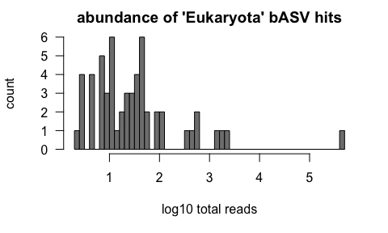

Because the most abundant eukASV returned zero hits to `nr`, even with discontinuous megablast for dissimilar sequences, we will go ahead and discard this ASV from the data. Inspecting the top 50 blast hits for the remaining eukASVs reveals an assortment of poor hits ($70-90%% identity) to fungal mt 16S, Arabidopsis genomic loci, or else there were no matches that passed even the default `blastn` criteria for returning a hit.

The sensible, if slightly expedient, approach will be to simply exclude all bASVs annotated as Eukaryota on the basis of their (1) terrible database matches, and (2) low overall abundance.

This leaves us with a total of 680 bASVs to sort through. Next let’s inspect the taxonomy and abundance distributions of these remaining bASVs:

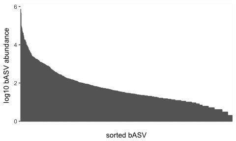

Most of the data comes from a small proportion of the ASVs. This is seen more clearly in the plot below, which depicts the cumulative sum of the data as a function of the fraction of the abundance-sorted bASVs:

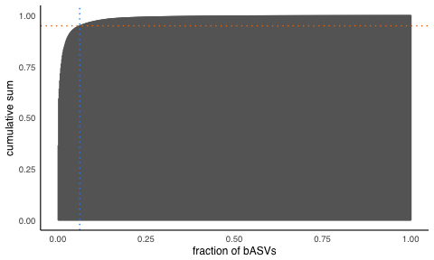

We can see that 42 bASVs (6.18 percent) comprise 95% of the sequence counts. This is a highly skewed abundance distribution. Let’s take a closer look at these 42 bASVs in more detail:

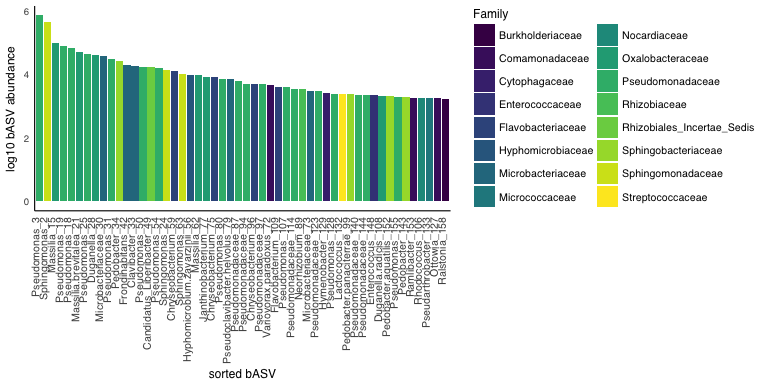

Asside from the first two super-abundant bASVs (*Pseudomonas* and *Sphingomonas*), the rest of these top 42 bASVs are quite even in their total abundance.

Let’s clean up the lower part of the bASV distribution by removing putatively spurious ASVs with no taxonomic designation whatsoever. These all have “none” in `unique.id`. We’re going to also exclude all ASVs with no taxonomic designation at Class-level or higher, which encompasses the “nones”, as well as any Archaea:

Removing these drops us by 59 bASVs and removes 6452 total sequences (0.14 percent of the data).

For now, let’s put any further analyses aside and instead construct the final ASV table that we will export to begin the analyses. I order to do this, we need to export two data file:

```r
write.csv(ASV8, file = here("data/ASV_table_26-JUN-2018.csv"), quote=F, row.names=F)
```

[output not shown]

## Examining bASVs by Family in more detail

All of the bASVs included in the final data frames above are those that do not look spurious and do not match host-derived cp or mt 16S. However, there still may be legit bASVs which nonetheless do not belong in our dataset. These include (a) those arising from index cross-contamination during demultiplexing from other sequencing projects, and (b) those with abundance/prevalence patterns consistent with sample contamination.

```r
# ASV8 <- read.csv(here("data/ASV_table_26-JUN-2018.csv"), row.names = 1)
# bTAX4 <- read.csv(here("data/bTAX_table_26-JUN-2018.csv"), row.names = 1)

# bTAX4$rel <- bTAX4$total / sum(bTAX4$total)
# length(bTAX4[bTAX4$rel > 0.01,'unique.id'])

bTAX4$rel <- bTAX4$total / sum(bTAX4$total)

# define set that is present in EL
bTAX4$in_EL <- 0
bTAX4$in_EL[bTAX4$unique.id %in% names(ELD)] <- 1

# define set that is present in NB
bTAX4$in_NP <- 0
bTAX4$in_NP[bTAX4$unique.id %in% names(NPD)] <- 1

# define sets present in each data-set:
bTAX5 <-  bTAX4[bTAX4$in_EL > 0, ]
bTAX6 <- bTAX4[bTAX4$in_NP > 0, ]
```

Step 1: Examining Family-wise abundance and prevalence patterns: